# Reproducible Research: Peer Assessment 1

## Loading and preprocessing the data

```r
#load the data
activityData <- read.csv(unz("activity.zip", "activity.csv"), stringsAsFactors=FALSE)
#transform the date column from string to date
activityData$date <- as.Date(activityData$date, '%Y-%m-%d')
```

## What is mean total number of steps taken per day?

- Make a histogram of the total number of steps taken each day

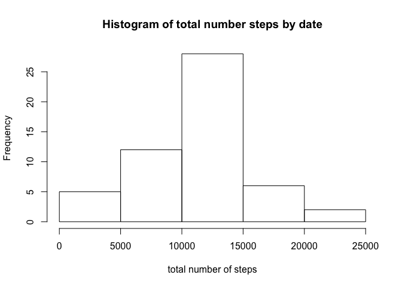

```r
activityDataByDate <- aggregate(activityData$steps, list(date = activityData$date), sum)
hist(activityDataByDate$x, xlab = "total number of steps", main = "Histogram of total number steps by date")
```

- Calculate and report the mean and median total number of steps taken per day

```r
mean(activityDataByDate$x, na.rm = TRUE)
```

```
## [1] 10766.19
```

```r
median(activityDataByDate$x, na.rm = TRUE)
```

```
## [1] 10765
```

## What is the average daily activity pattern?

- Make a time series plot (i.e. type = “l”) of the 5-minute interval (x-axis) and the average number of steps taken, averaged across all days (y-axis)

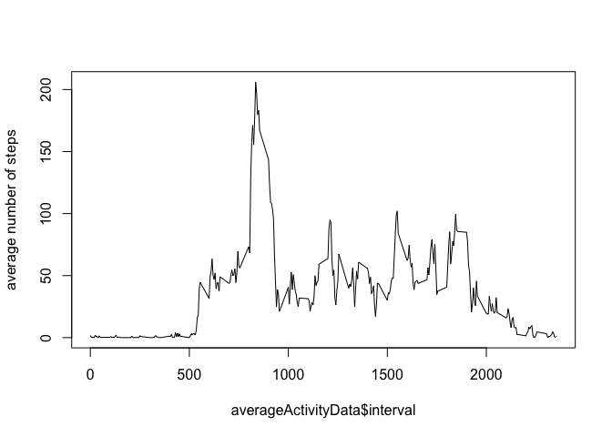

```r
averageActivityData <- aggregate(activityData$steps,
                                 list(interval=activityData$interval), mean, na.rm=TRUE)
plot(averageActivityData$interval, averageActivityData$x, type = 'l', ylab="average number of steps")
```

- Which 5-minute interval, on average across all the days in the dataset, contains the maximum number of steps?

```r
averageActivityData$interval[which.max(averageActivityData$x)]
```

```
## [1] 835
```